# Cars Analysis

Alejandro Fernandez Benages

17/03/2021

# Libraries

```r
#install.packages('tidyverse')
#install.packages(readr)
library("readr")
library(ggplot2)
```

# Load CSV

```r
IrisDataset <- read.csv('cars.csv')
```

# 1. EDA

## 1.1 Knowing the data

```r
# To list the attributes of the data set.
attributes(cars)
```

```
## $names
## [1] "speed" "dist"
##
## $class
## [1] "data.frame"
##
## $row.names
##  [1]  1  2  3  4  5  6  7  8  9 10 11 12 13 14 15 16 17 18 19 20 21 22 23 24 25
## [26] 26 27 28 29 30 31 32 33 34 35 36 37 38 39 40 41 42 43 44 45 46 47 48 49 50
```

```r
# To print the min, max, mean, median, and quartiles of each attribute.
summary(cars)
```

```
##      speed           dist
##  Min.   : 4.0   Min.   :  2.00
##  1st Qu.:12.0   1st Qu.: 26.00
##  Median :15.0   Median : 36.00
##  Mean   :15.4   Mean   : 42.98
##  3rd Qu.:19.0   3rd Qu.: 56.00
##  Max.   :25.0   Max.   :120.00
```

```r
# To display the structure of your data set.
str(cars)
```

```
## 'data.frame':    50 obs. of  2 variables:
##  $ speed: num  4 4 7 7 8 9 10 10 10 11 ...
##  $ dist : num  2 10 4 22 16 10 18 26 34 17 ...
```

```r
# To get th names of the attributes within your data set.
names(cars)
```

```
## [1] "speed" "dist"
```

## 1.2 Some Plots

### Variable: SPEED

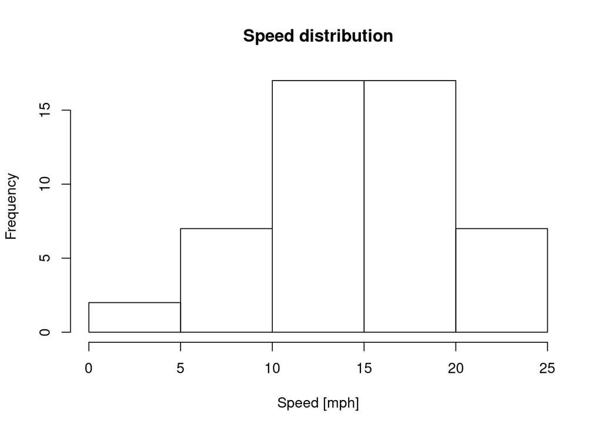

```r
hist(cars$speed,
     main="Speed distribution", xlab="Speed [mph]")
```

A Histogram reveals that the most frequent speed of cars is between 10 to 20.

### Variable: STOPPING DISTANCE

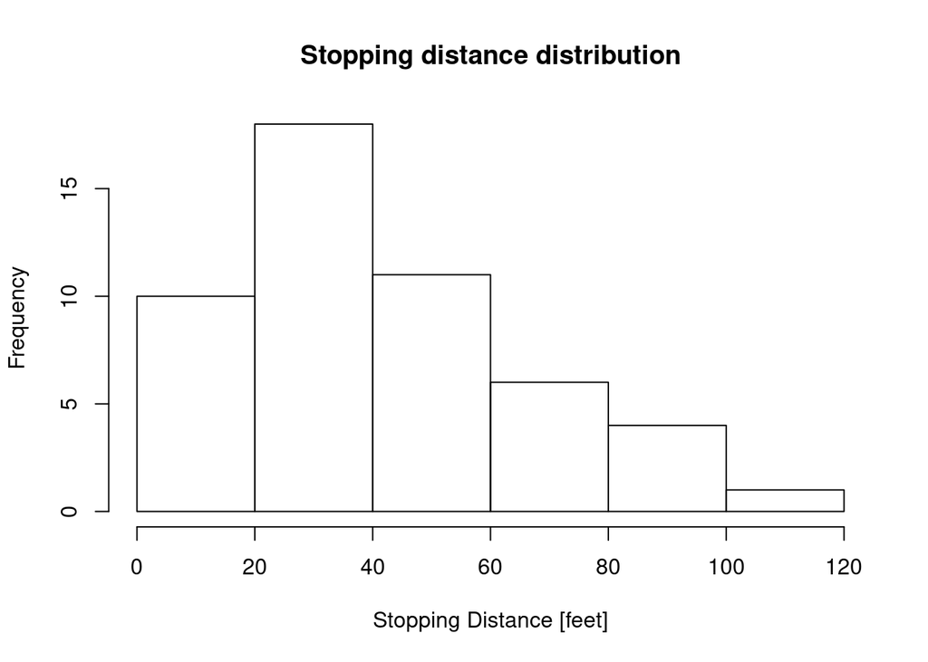

```r
hist(cars$dist,
     main="Stopping distance distribution", xlab="Stopping Distance [feet]")
```

The most frequent distance of most cars is between 20 to 40.

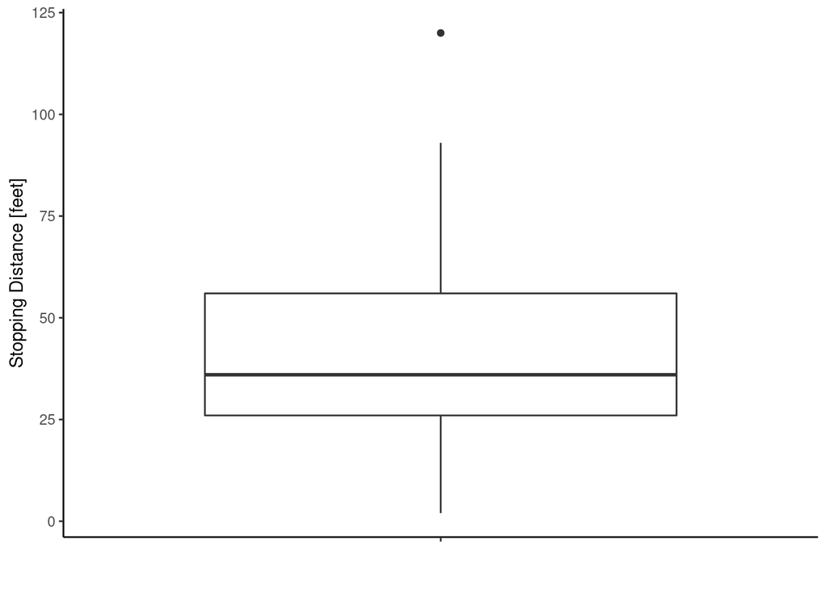

```r
ggplot(data = cars, aes(x = "", y = dist)) +
  geom_boxplot()+ theme_classic()+
  xlab("")+ylab("Stopping Distance [feet]")
```

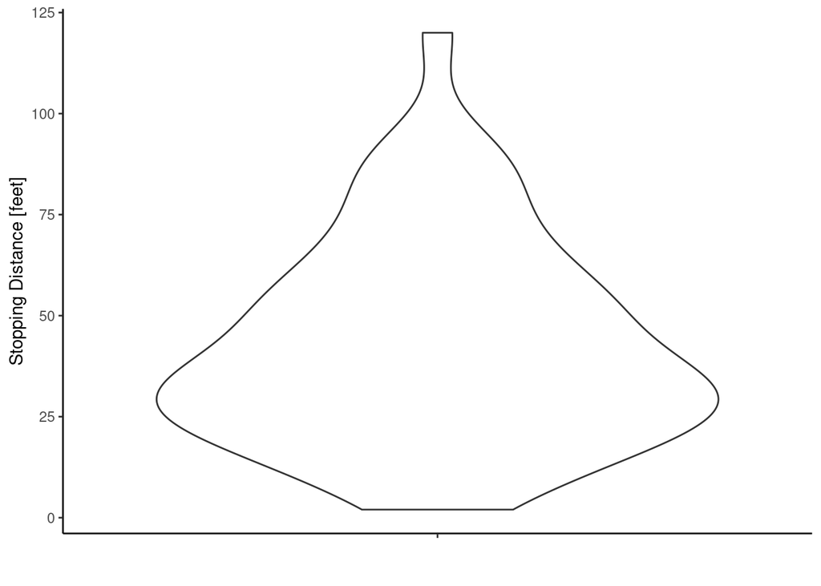

```r
ggplot(data = cars, aes(x = "", y = dist)) +
  geom_violin()+ theme_classic()+
  xlab("")+ylab("Stopping Distance [feet]")
```

### Normal Quantile Plot is a way to see if your data is normally distributed.

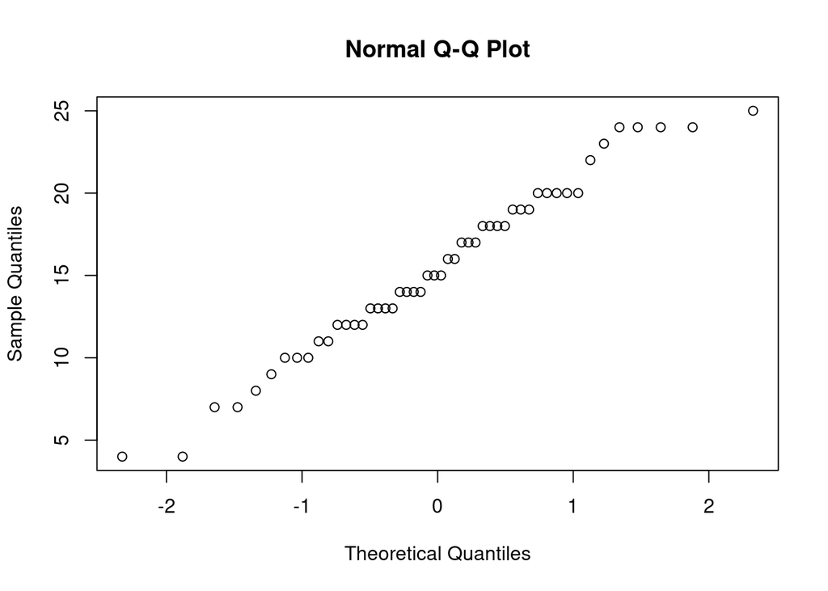

```r
qqnorm(cars$speed)
```

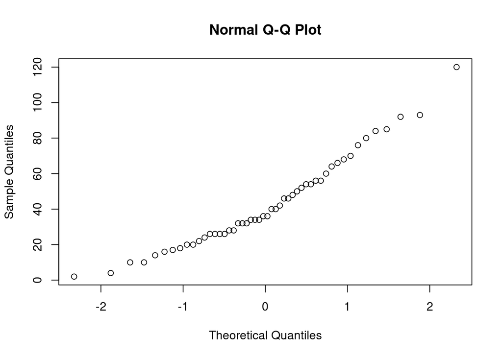

```r
qqnorm(cars$dist)
```

### Scatter plot of Speed vs Distance

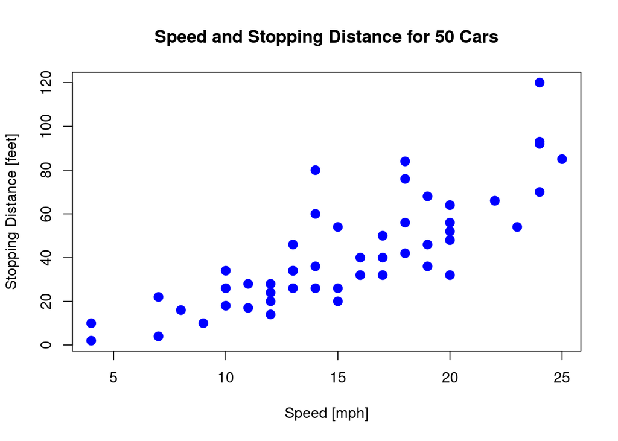

```r
plot(cars, col='blue', pch=20, cex=2,
     main="Speed and Stopping Distance for 50 Cars",
     xlab="Speed [mph]", ylab="Stopping Distance [feet]")
```

There is a clear positive correlation between Speed and Distance.

## 1.3 Missing Values?

If there are, the summarye() will count how many NA’s you have.

```r
summary(cars)
```

```
##      speed           dist
##  Min.   : 4.0   Min.   :  2.00
##  1st Qu.:12.0   1st Qu.: 26.00
##  Median :15.0   Median : 36.00
##  Mean   :15.4   Mean   : 42.98
##  3rd Qu.:19.0   3rd Qu.: 56.00
##  Max.   :25.0   Max.   :120.00
```

Also you can show your NA’s through logical data. (TRUE if it’s missing, FALSE if it’s not.)

```r
is.na(cars)
```

```
##       speed  dist
##  [1,] FALSE FALSE
##  [2,] FALSE FALSE
##  [3,] FALSE FALSE
##  [4,] FALSE FALSE
##  [5,] FALSE FALSE
##  [6,] FALSE FALSE
##  [7,] FALSE FALSE
##  [8,] FALSE FALSE
##  [9,] FALSE FALSE
## [10,] FALSE FALSE
## [11,] FALSE FALSE
## [12,] FALSE FALSE
## [13,] FALSE FALSE
## [14,] FALSE FALSE
```

[output cut: 36 more lines]

Replace the missing values with the mean, which is common technique, but **something to use with care with as it can skew the data**.

```r
#DatasetName$ColumnName[is.na(DatasetName$ColumnName)]<-mean(DatasetName$ColumnName,na.rm = TRUE)
```

# 2. Testing and Training Sets

First of all, define a seed to get *reproducible experiments*.

```r
set.seed(122)
```

These two lines calculate the sizes of each set *but do not create* the sets:

```r
trainSize<-round(nrow(cars)*0.7) # 70/30%
testSize<-nrow(cars)-trainSize
```

Just to check the dimension of the empty vectors.

```r
print(trainSize)
```

```
## [1] 35
```

```r
print(testSize)
```

```
## [1] 15
```

How do you create the **train/test sets**?. We also want these sets to be in a randomized order, which will help to create an optimal model. To perform this, you need to run these three lines of code.

```r
training_indices<-sample(seq_len(nrow(cars)),size =trainSize)
trainSet<-cars[training_indices,]
testSet<-cars[-training_indices,]
```

# 3. Linear Regression

The next step is to predict the cars distances through the speed of the cars. To do this, we’ll be using the prediction function – predict()

A regression model of *first grade*, can be defined by the equation of a straight line.

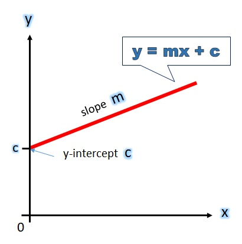

Replacing some values
$$Distance = slope * Speed + y.intercept$$

the syntaxis on R is quite straightforward $lm(Y ~ X, dataset)$ where **lm** stands for *linear model*.

To avoid **overfitting**, we use the **Train Set** to fit the model.

```r
# The basic line of code for the linear model function.
cars_regression <-lm(dist ~ speed, trainSet)
```

thats all!. Now to see the metrics of the model, just call **summary()**

```r
summary(cars_regression)
```

```
##
## Call:
## lm(formula = dist ~ speed, data = trainSet)
##
## Residuals:
##     Min      1Q  Median      3Q     Max
## -26.565 -10.236  -2.565   9.379  42.929
##
## Coefficients:
##             Estimate Std. Error t value Pr(>|t|)
## (Intercept)  -13.082      8.563  -1.528    0.136
## speed          3.582      0.506   7.080 4.18e-08 ***
## ---
## Signif. codes:  0 '***' 0.001 '**' 0.01 '*' 0.05 '.' 0.1 ' ' 1
##
## Residual standard error: 15.75 on 33 degrees of freedom
## Multiple R-squared:  0.603,  Adjusted R-squared:  0.591
## F-statistic: 50.13 on 1 and 33 DF,  p-value: 4.181e-08
```

## 3.1 Predictions

To make predictions, we use the **Test Set**.

```r
cars_predictions <- predict(cars_regression, testSet)
cars_predictions
```

```
##         1         3         8        11        14        16        17        18
##  1.247655 11.994691 22.741727 26.324072 29.906418 33.488763 33.488763 33.488763
##        20        22        30        32        33        38        49
## 37.071108 37.071108 47.818144 51.400490 51.400490 54.982835 72.894561
```

**Confidence in your predictions**: In order to have an idea about the accuracy of the predictions, you can ask for intervals around your prediction.

```r
predict(cars_regression,testSet, interval='confidence')
```

```
##          fit        lwr      upr
## 1   1.247655 -12.321487 14.81680
## 3  11.994691   1.186675 22.80271
## 8  22.741727  14.460418 31.02304
## 11 26.324072  18.791390 33.85676
## 14 29.906418  23.049158 36.76368
## 16 33.488763  27.210054 39.76747
## 17 33.488763  27.210054 39.76747
## 18 33.488763  27.210054 39.76747
## 20 37.071108  31.245146 42.89707
## 22 37.071108  31.245146 42.89707
## 30 47.818144  42.321088 53.31520
## 32 51.400490  45.637230 57.16375
## 33 51.400490  45.637230 57.16375
## 38 54.982835  48.791536 61.17413
## 49 72.894561  63.111447 82.67768
```

```r
predict(cars_regression,testSet, interval='prediction')
```

```
##          fit        lwr       upr
## 1   1.247655 -33.547942  36.04325
## 3  11.994691 -21.819880  45.80926
## 8  22.741727 -10.351959  55.83541
## 11 26.324072  -6.590260  59.23841
## 14 29.906418  -2.859937  62.67277
## 16 33.488763   0.838584  66.13894
## 17 33.488763   0.838584  66.13894
## 18 33.488763   0.838584  66.13894
## 20 37.071108   4.504963  69.63725
## 22 37.071108   4.504963  69.63725
## 30 47.818144  15.309228  80.32706
## 32 51.400490  18.845503  83.95548
## 33 51.400490  18.845503  83.95548
## 38 54.982835  22.349352  87.61632
## 49 72.894561  39.393497 106.39563
```

## 3.2 Fitting a line

As we used a model with a first grade equation, the parameters that define the line that fits our model are 2, **slope** and **y-Intersection**.

[output not shown]

So, now we can plot both, the dots of our data, and the line that fits them.

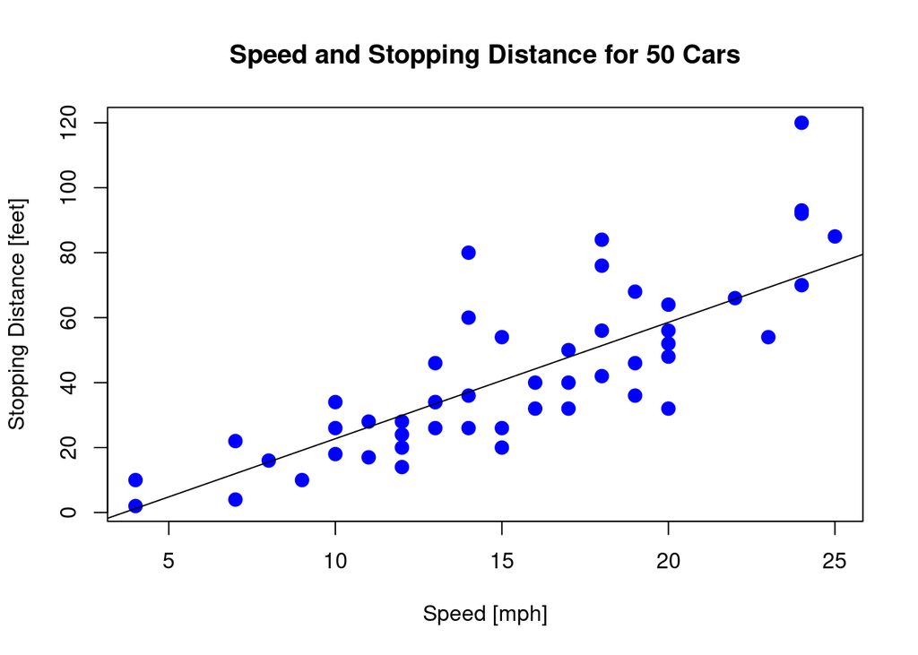

```r
plot(cars, col='blue', pch=20, cex=2,
     main="Speed and Stopping Distance for 50 Cars",
     xlab="Speed [mph]", ylab="Stopping Distance [feet]")


abline(-13.082, 3.582)
```

## 3.3 Residual plots

A residual is the difference between an observed value and a predicted value in regression analysis.

It is calculated as: $Residual = Observed.Value – Predicted.Value$

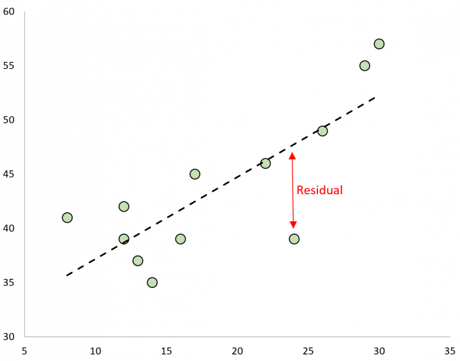

To get the residuals of out model

```r
res <- resid(cars_regression)
```

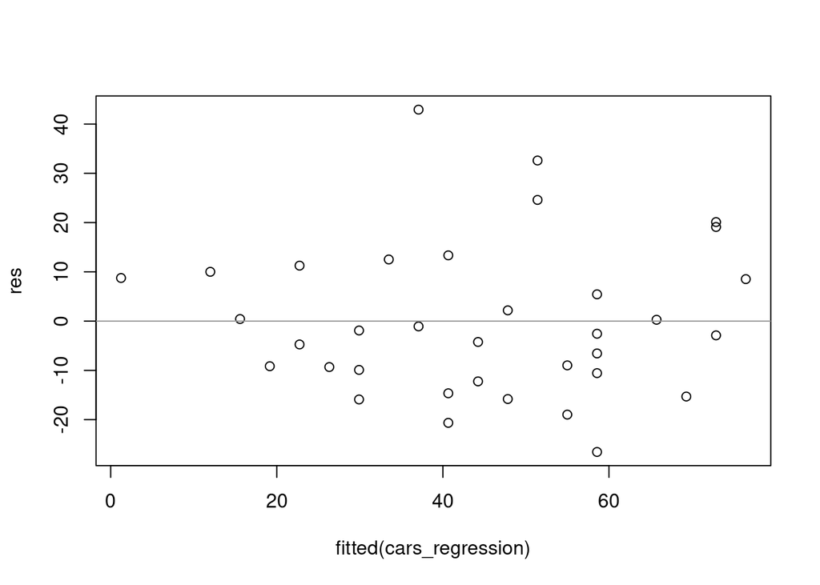

```r
#produce residual vs. fitted plot
plot(fitted(cars_regression), res)

#add a horizontal line at 0
abline(h = 0, col = "gray60")
```